# Öneri Sistemleri

## Problem Tanımı

```python
film=pd.read_csv("data/movies.csv");film.head(5)
```

|  | movieId | title | genres |
| --- | --- | --- | --- |
| 0 | 1 | Toy Story (1995) | Adventure\|Animation\|Children\|Comedy\|Fantasy |
| 1 | 2 | Jumanji (1995) | Adventure\|Children\|Fantasy |
| 2 | 3 | Grumpier Old Men (1995) | Comedy\|Romance |
| 3 | 4 | Waiting to Exhale (1995) | Comedy\|Drama\|Romance |
| 4 | 5 | Father of the Bride Part II (1995) | Comedy |

```python
film["tür"]=film.genres.str.strip().str.split('[\W_]+')
```

```python
satırlar = list()
for row in film[['movieId', 'tür']].iterrows():
    r = row[1]
    for tür in r.tür:
        satırlar.append((r.movieId, tür))

nitelik_df = pd.DataFrame(satırlar, columns=['movieId', 'tür'])
nitelik_listesi=nitelik_df.tür.unique().tolist();nitelik_listesi.remove('');nitelik_listesi
nitelik_df.head(2)
```

|  | movieId | tür |
| --- | --- | --- |
| 0 | 1 | Adventure |
| 1 | 1 | Animation |

```python
nitelik_df["say"]=1
nitelik_pivot=pd.pivot_table(nitelik_df, values="say", index=['movieId'],columns=['tür'], aggfunc=np.sum)
nitelik_pivot=pd.pivot_table(nitelik_df, values="say", index=['movieId'],columns=['tür'], aggfunc=np.sum)
nitelik_pivot=nitelik_pivot.reset_index()
nitelik_pivot.drop([''], axis=1,inplace=True)
nitelik_pivot=nitelik_pivot.merge(film[["movieId","title"]],how="left",on="movieId")
# #kelimeler_eklenecek=kelimeler_eklenecek.fillna(0)
derece=pd.read_csv("data/ratings.csv");derece.head(2)
```

|  | userId | movieId | rating | timestamp |
| --- | --- | --- | --- | --- |
| 0 | 1 | 1 | 4.0 | 964982703 |
| 1 | 1 | 3 | 4.0 | 964981247 |

```python
eğitim_verisi=derece.merge(film,how="left",on="movieId")[["userId","title","rating"]]
eğitim_verisi_pivot=pd.pivot_table(eğitim_verisi, values="rating", index=['title'],columns=['userId'], aggfunc=np.mean)
eğitim_verisi=eğitim_verisi_pivot.reset_index().merge(nitelik_pivot,how="left",on="title")
eğitim_verisi.drop(['movieId' ], axis=1,inplace=True)
```

```python
eğitim_verisi.dropna(thresh=250)
```

|  | title | 1 | 2 | 3 | 4 | 5 | 6 | 7 | 8 | 9 | ... | Mystery | Noir | Romance | Sci | Thriller | War | Western | genres | listed | no |
| --- | --- | --- | --- | --- | --- | --- | --- | --- | --- | --- | --- | --- | --- | --- | --- | --- | --- | --- | --- | --- | --- |
| 3161 | Forrest Gump (1994) | 4.0 | NaN | NaN | NaN | NaN | 5.0 | 5.0 | 3.0 | NaN | ... | NaN | NaN | 1.0 | NaN | NaN | 1.0 | NaN | NaN | NaN | NaN |
| 5515 | Matrix, The (1999) | 5.0 | NaN | NaN | 1.0 | NaN | NaN | NaN | NaN | NaN | ... | NaN | NaN | NaN | 1.0 | 1.0 | NaN | NaN | NaN | NaN | NaN |
| 6868 | Pulp Fiction (1994) | 3.0 | NaN | NaN | 1.0 | 5.0 | 2.0 | NaN | 4.0 | NaN | ... | NaN | NaN | NaN | NaN | 1.0 | NaN | NaN | NaN | NaN | NaN |
| 7597 | Shawshank Redemption, The (1994) | NaN | 3.0 | NaN | NaN | 3.0 | 5.0 | NaN | 5.0 | NaN | ... | NaN | NaN | NaN | NaN | NaN | NaN | NaN | NaN | NaN | NaN |
| 7684 | Silence of the Lambs, The (1991) | 4.0 | NaN | NaN | 5.0 | NaN | 4.0 | 5.0 | 4.0 | NaN | ... | NaN | NaN | NaN | NaN | 1.0 | NaN | NaN | NaN | NaN | NaN |
| 8005 | Star Wars: Episode IV - A New Hope (1977) | 5.0 | NaN | NaN | 5.0 | NaN | NaN | 5.0 | NaN | NaN | ... | NaN | NaN | NaN | 1.0 | NaN | NaN | NaN | NaN | NaN | NaN |

6 rows × 635 columns

## Örnek Film- İzleyici (Kullanıcı) Puan Tahmini

### Notasyon

$n_u$ : Kullanıcı Sayısı

$ n_m $ : Film Sayısı

Film indisi= $i$ , kullanıcı indisi=$j $

$ r_{(i,j)} $ : Eğer kullanıcı filmi puanladı ise 1

$y_{(i,j)}$ : indis $(i,j)=1$ iken verilen puanın değeri

[figure not shown]

```python
nu=len(eğitim_verisi.columns)-len(nitelik_listesi);print("Kullanıcı Sayısı" ,nu,"kişidir.")
```

```
Kullanıcı Sayısı 611 kişidir.
```

```python
nm=eğitim_verisi.shape[0];print("Film Sayısı" ,nm,"kişidir.")
```

```
Film Sayısı 9724 kişidir.
```

```python
eğitim_verisi.dropna(thresh=200)[["title"]+nitelik_listesi].head(5)
```

|  | title | Adventure | Animation | Children | Comedy | Fantasy | Romance | Drama | Action | Crime | ... | War | Musical | Documentary | IMAX | Western | Film | Noir | no | genres | listed |
| --- | --- | --- | --- | --- | --- | --- | --- | --- | --- | --- | --- | --- | --- | --- | --- | --- | --- | --- | --- | --- | --- |
| 405 | American Beauty (1999) | NaN | NaN | NaN | NaN | NaN | 1.0 | 1.0 | NaN | NaN | ... | NaN | NaN | NaN | NaN | NaN | NaN | NaN | NaN | NaN | NaN |
| 565 | Apollo 13 (1995) | 1.0 | NaN | NaN | NaN | NaN | NaN | 1.0 | NaN | NaN | ... | NaN | NaN | NaN | 1.0 | NaN | NaN | NaN | NaN | NaN | NaN |
| 1337 | Braveheart (1995) | NaN | NaN | NaN | NaN | NaN | NaN | 1.0 | 1.0 | NaN | ... | 1.0 | NaN | NaN | NaN | NaN | NaN | NaN | NaN | NaN | NaN |
| 3014 | Fight Club (1999) | NaN | NaN | NaN | NaN | NaN | NaN | 1.0 | 1.0 | 1.0 | ... | NaN | NaN | NaN | NaN | NaN | NaN | NaN | NaN | NaN | NaN |
| 3161 | Forrest Gump (1994) | NaN | NaN | NaN | 1.0 | NaN | 1.0 | 1.0 | NaN | NaN | ... | 1.0 | NaN | NaN | NaN | NaN | NaN | NaN | NaN | NaN | NaN |

5 rows × 25 columns

## İçerik Üzerinden Puanlama

### Problemin Formulleştirilmesi

Her bir kullanıcı için katsayısı ($\theta$) öğrenilir. Ardından bu katsayılar ile niteliklerin (x) değerleri çarpılarak tahmini puanlar hesaplanır.

Formül : $ (\theta^j)^T *x_i $

$r^{(i,j)}$ : Eğer kullanıcı filmi puanladı ise 1

$y^{(i,j)}$ : indis (i,j)=1 iken verilen puanın değeri

$\theta^{(j)}$ : j kullanıcı için katsayı vektörü

$x^{(i)}$ : i filmi için nitelik vektörü

Her bir kullanıcı için tahmini puan $ (\theta^{(j)})^T *x_i$

$ m^{(j)} $: $j$ kullanıcısı tarafından puanlanan toplam film adedi

j kullanıcısı için katsayı($\theta_j$) hesaplanması :

$min_{\theta^{(j)}} 1/2 \begin{equation}\sum_{i:r(i,j)=1} ((\theta^j)^T *x_i - y^{(i,j)})^2 \end{equation} $

$min_{\theta^j} 1/2 \begin{equation}\sum_{i:r(i,j)=1} ((\theta^j)^T *x_i - y^{(i,j)})^2 \ + \lambda/2 \sum_{k=1}^n (\theta_k^j)^2 \end{equation} $

### Optimizasyon Hedefi

* $ \theta^{(j)} $ katsayısını j kullanıcısı için hesaplamak için kullanılacak formül :

$min_{\theta^j} 1/2 \begin{equation}\sum_{i:r(i,j)=1} ((\theta^j)^T *x_i - y^{(i,j)})^2 \ + \lambda/2 \sum_{k=1}^n (\theta_k^j)^2 \end{equation} $

* $ \theta^{(1)} ,\theta^{(2)} ,\theta^{(3)},...,\theta^{(n_u)} $ katsayılarını için hesaplamak için kullanılacak formül :

$min_{\theta^{(1)} ,..,\theta^{(n_u)}} 1/2 \begin{equation}\sum_{i:r(i,j)=1} ((\theta^j)^T *x_i - y^{(i,j)})^2 \ + \lambda/2 \sum_{j=1}^{n_u} \sum_{k=1}^n (\theta_k^j)^2 \end{equation} $

### Optimizasyon Algoritması

\begin{equation} J_{(\theta^{(1)} ,..,\theta^{(n_u)})}=1/2*\sum_{i:r(i,j)=1} ((\theta^j)^T *x_i - y^{(i,j)})^2 \ + \lambda/2 \sum_{j=1}^{n_u} \sum_{k=1}^n (\theta_k^j)^2 \end{equation}

Dereceli Azaltma:

\begin{equation}\ \theta_k^{(j)} := \theta_k^{(j)}-a*\sum_{i:r(i,j)=1} ((\theta^{(j)})^T *x^{(i)} - y^{(i,j)})*x^{(i)} \ \ \ \ \ (k=0 \ \ için) \end{equation}

\begin{equation}\ \theta_k^{(j)} := \theta_k^{(j)}-a*(\sum_{i:r(i,j)=1} ((\theta^{(j)})^T *x^{(i)} - y^{(i,j)})*x^{(i)} + \lambda*\theta_k^{(j)} )\ \ \ \ \ (k\neq0 \ \ için) \end{equation}

\begin{equation}\ \frac{\partial J(\theta_0,\theta_1,...\theta_n)}{\partial \theta_k^{(j)}}=(\sum_{i:r(i,j)=1} ((\theta^{(j)})^T *x^{(i)} - y^{(i,j)})*x^{(i)} + \lambda*\theta_k^{(j)} )\ \end{equation}

### İşbirliğine Dayalı Filtreleme (collaborative filtering)

```python
örnek_listesi=["title", 610 , 448 , 599 , 474 , 414,380,274,606,"Thriller",  "Comedy","Drama","Action","Romance" ]
örnek_veri=eğitim_verisi[örnek_listesi].dropna(thresh=11)
örnek_veri.set_index(["title"],inplace=True);örnek_veri.head(5)
```

| title | 610 | 448 | 599 | 474 | 414 | 380 | 274 | 606 | Thriller | Comedy | Drama | Action | Romance |
| --- | --- | --- | --- | --- | --- | --- | --- | --- | --- | --- | --- | --- | --- |
| Apocalypse Now (1979) | 5.0 | 4.0 | 5.0 | 3.5 | 5.0 | 4.0 | 4.0 | 4.5 | NaN | NaN | 1.0 | 1.0 | NaN |
| Batman (1989) | 4.5 | 3.0 | 3.5 | 4.0 | 4.0 | 3.0 | 3.0 | 3.5 | 1.0 | NaN | NaN | 1.0 | NaN |
| Beverly Hills Cop (1984) | NaN | 5.0 | 3.5 | 2.0 | 4.0 | 4.0 | 4.0 | 2.5 | NaN | 1.0 | 1.0 | 1.0 | NaN |
| Big (1988) | NaN | 4.0 | 3.5 | 4.0 | 4.0 | 3.0 | 3.0 | 3.0 | NaN | 1.0 | 1.0 | NaN | 1.0 |
| Blade Runner (1982) | 5.0 | 4.0 | 4.5 | 3.0 | 5.0 | 5.0 | 2.5 | 5.0 | 1.0 | NaN | NaN | 1.0 | NaN |

Nitelik Listesi

*Thriller(x1)

*Comedy(x2)

*Drama(x3)

*Action(x4)

*Romance(x5)

```python
örnek_veri.rename(columns={"Thriller": "Thriller(x1)", "Comedy": "Comedy(x2)","Drama": "Drama(x3)","Action": "Action(x4)","Romance": "Romance(x5)"},inplace=True)
örnek_veri.rename(columns={ 610 : "610(theta0)",  448 : "448(theta1)",599: "599(theta2)",474: "474(theta3)",414: "414(theta4)",380:"380(theta5)",274:"274(theta6)",606:"606(theta7)"},inplace=True)
örnek_kullanıcı_listesi=[  "610(theta0)",   "448(theta1)",  "599(theta2)",  "474(theta3)",  "414(theta4)", "380(theta5)",  "274(theta6)", "606(theta7)"]
örnek_nitelik_listesi=["Yanlılık(x0)","Thriller(x1)" ,"Comedy(x2)", "Drama(x3)","Action(x4)", "Romance(x5)"]
örnek_veri["Yanlılık(x0)"]=1
örnek_veri=örnek_veri[örnek_kullanıcı_listesi+örnek_nitelik_listesi];örnek_veri.head(5)
```

| title | 610(theta0) | 448(theta1) | 599(theta2) | 474(theta3) | 414(theta4) | 380(theta5) | 274(theta6) | 606(theta7) | Yanlılık(x0) | Thriller(x1) | Comedy(x2) | Drama(x3) | Action(x4) | Romance(x5) |
| --- | --- | --- | --- | --- | --- | --- | --- | --- | --- | --- | --- | --- | --- | --- |
| Apocalypse Now (1979) | 5.0 | 4.0 | 5.0 | 3.5 | 5.0 | 4.0 | 4.0 | 4.5 | 1 | NaN | NaN | 1.0 | 1.0 | NaN |
| Batman (1989) | 4.5 | 3.0 | 3.5 | 4.0 | 4.0 | 3.0 | 3.0 | 3.5 | 1 | 1.0 | NaN | NaN | 1.0 | NaN |
| Beverly Hills Cop (1984) | NaN | 5.0 | 3.5 | 2.0 | 4.0 | 4.0 | 4.0 | 2.5 | 1 | NaN | 1.0 | 1.0 | 1.0 | NaN |
| Big (1988) | NaN | 4.0 | 3.5 | 4.0 | 4.0 | 3.0 | 3.0 | 3.0 | 1 | NaN | 1.0 | 1.0 | NaN | 1.0 |
| Blade Runner (1982) | 5.0 | 4.0 | 4.5 | 3.0 | 5.0 | 5.0 | 2.5 | 5.0 | 1 | 1.0 | NaN | NaN | 1.0 | NaN |

```python
# X matrix
örnek_veri[örnek_nitelik_listesi].head()
```

| title | Yanlılık(x0) | Thriller(x1) | Comedy(x2) | Drama(x3) | Action(x4) | Romance(x5) |
| --- | --- | --- | --- | --- | --- | --- |
| Apocalypse Now (1979) | 1 | NaN | NaN | 1.0 | 1.0 | NaN |
| Batman (1989) | 1 | 1.0 | NaN | NaN | 1.0 | NaN |
| Beverly Hills Cop (1984) | 1 | NaN | 1.0 | 1.0 | 1.0 | NaN |
| Big (1988) | 1 | NaN | 1.0 | 1.0 | NaN | 1.0 |
| Blade Runner (1982) | 1 | 1.0 | NaN | NaN | 1.0 | NaN |

```python
# x^0

x0=örnek_veri.loc["Apocalypse Now (1979)",örnek_nitelik_listesi];x0
```

```
Yanlılık(x0)    1.0
Thriller(x1)    NaN
Comedy(x2)      NaN
Drama(x3)       1.0
Action(x4)      1.0
Romance(x5)     NaN
Name: Apocalypse Now (1979), dtype: float64
```

```python
x0.fillna(0)
```

```
Yanlılık(x0)    1.0
Thriller(x1)    0.0
Comedy(x2)      0.0
Drama(x3)       1.0
Action(x4)      1.0
Romance(x5)     0.0
Name: Apocalypse Now (1979), dtype: float64
```

```python
# theta^0 = ?
theta0=np.array([1,2,3,3,1,2]);theta0
```

```
array([1, 2, 3, 3, 1, 2])
```

$(\theta^{(0)})^T *x^{(0)}$

```python
np.dot(theta0.T,x0.fillna(0))
```

```
5.0
```

```python
# 610 kullanıcı 5 puan vermişti.
örnek_veri.loc["Apocalypse Now (1979)","610(theta0)"]
```

```
5.0
```

```python
theta1=np.array([0,2,3,3,1,2]);theta1
```

```
array([0, 2, 3, 3, 1, 2])
```

$(\theta^{(1)})^T *x^{(0)}$

```python
np.dot(theta1.T,x0.fillna(0))
```

```
4.0
```

```python
# 448 kullanıcı 4 puan vermişti.
örnek_veri.loc["Apocalypse Now (1979)","448(theta1)"]
```

```
4.0
```

### Nitelik için Optimizasyon Algoritması

$x^{(i)}$ niteliklerini $\theta_0,\theta_1,...\theta_n$ bilinirken için hesaplamak için kullanılacak formül :

\begin{equation} min_{(x^{(i)})} \ \ 1/2*\sum_{i:r(i,j)=1} ((\theta^j)^T *x_i - y^{(i,j)})^2 \ + \lambda/2 \sum_{k=1}^n (x_k^{(i)})^2 \end{equation}

$x^{(1)},x^{(2)},x^{(3)},..,x^{(m)}$ niteliklerini $\theta_0,\theta_1,...\theta_n$ bilinirken için hesaplamak için kullanılacak formül :

\begin{equation} min_{ x^{(1)},x^{(2)},x^{(3)},..,x^{(m)} } \ \ 1/2*\sum_{i:r(i,j)=1} ((\theta^j)^T *x_i - y^{(i,j)})^2 \ + \lambda/2 \sum_{i=1}^{n_m} \sum_{k=1}^n (x_k^{(i)})^2 \end{equation}

### Sonuç olarak : İşbirliğine Dayalı Filtreleme (collaborative filtering)

$x^{(1)},x^{(2)},x^{(3)},..,x^{(m)}$ niteliklerini biliyorsak , $\theta_0,\theta_1,...\theta_n$ katsayılarını hesaplayabiliriz.

$\theta_0,\theta_1,...\theta_n$ katsayılarını biliyorsak , $x^{(1)},x^{(2)},x^{(3)},..,x^{(m)}$ niteliklerini hesaplayabiliriz

Tahminimiz : $\theta -> x->\theta -> x->\theta -> x->\theta -> ... $ şeklinde olacaktır.

### İşbirliğine Dayalı Filtreleme (collaborative filtering) Optimizasyon Hedefi

$x^{(1)},x^{(2)},x^{(3)},..,x^{(m)}$ niteliklerini bilirken $ \theta^{(1)} ,\theta^{(2)} ,\theta^{(3)},...,\theta^{(n_u)} $ katsayılarını için hesaplamak için kullanılacak formül :

$min_{\theta^{(1)} ,..,\theta^{(n_u)}} 1/2 \begin{equation}\sum_{i:r(i,j)=1} ((\theta^j)^T *x_i - y^{(i,j)})^2 \ + \lambda/2 \sum_{j=1}^{n_u} \sum_{k=1}^n (\theta_k^j)^2 \end{equation} $

$ \theta^{(1)} ,\theta^{(2)} ,\theta^{(3)},...,\theta^{(n_u)} $ katsayılarını bilirken $x^{(1)},x^{(2)},x^{(3)},..,x^{(m)}$ niteliklerini için hesaplamak için kullanılacak formül :

$ min_{ x^{(1)},x^{(2)},x^{(3)},..,x^{(m)} } 1/2* \begin{equation} \sum_{i:r(i,j)=1} ((\theta^j)^T *x_i - y^{(i,j)})^2 \ + \lambda/2 \sum_{i=1}^{n_m} \sum_{k=1}^n (x_k^{(i)})^2 \end{equation} $

Aynı anda $ \theta^{(1)} ,\theta^{(2)} ,\theta^{(3)},...,\theta^{(n_u)} $ ve $x^{(1)},x^{(2)},x^{(3)},..,x^{(m)}$ minimize etmek için :

$ min_{( x^{(1)},..,x^{(m)}) ,(\theta^{(1)} ,..,\theta^{(n_u)}) } 1/2* \begin{equation} \sum_{i:r(i,j)=1} ((\theta^j)^T *x_i - y^{(i,j)})^2 \ + \lambda/2 \sum_{i=1}^{n_m} \sum_{k=1}^n (x_k^{(i)})^2+ \lambda/2 \sum_{j=1}^{n_u} \sum_{k=1}^n (\theta_k^j)^2 \end{equation} $

### İşbirliğine Dayalı Filtreleme (collaborative filtering) Algoritması

1. $x^{(1)},x^{(2)},x^{(3)},..,x^{(m)}$ , $ \theta^{(1)} ,\theta^{(2)} ,\theta^{(3)},...,\theta^{(n_u)} $ parametrelerine ufak rastgele sayılar atanır .

2. $ J( x^{(1)},..,x^{(m)}) ,(\theta^{(1)} ,..,\theta^{(n_u)}) $ değerini minimize etmek için "dereceli azaltma" veya "ileri optimizasyon" kullanılır. Bu parametrelere başlangıçta ufak rastgele sayılar atanır .

\begin{equation}\ x_k^{(i)} := x_k^{(i)}-a*(\sum_{i:r(i,j)=1} ((\theta^{(j)})^T *x^{(i)} - y^{(i,j)})*\theta_k^{(j)} + \lambda*x_k^{(i)})\ \end{equation}

\begin{equation}\ \theta_k^{(j)} := \theta_k^{(j)}-a*(\sum_{i:r(i,j)=1} ((\theta^{(j)})^T *x^{(i)} - y^{(i,j)})*x^{(i)} + \lambda*\theta_k^{(j)} )\ \end{equation}

3. $\theta$ katsayısına sahip kullanıcı ve $x$ nitelikleri hesaplanmış bir film için tahmini fill puanı $(\theta^T *x)$'e eşittir.

### Vektörleştirme : Düşük Rank Matris Faktorizasyonu (Vectorization : Low rank matrix factorization)

```python
örnek_veri.head(3)
```

| title | 610(theta0) | 448(theta1) | 599(theta2) | 474(theta3) | 414(theta4) | 380(theta5) | 274(theta6) | 606(theta7) | Yanlılık(x0) | Thriller(x1) | Comedy(x2) | Drama(x3) | Action(x4) | Romance(x5) |
| --- | --- | --- | --- | --- | --- | --- | --- | --- | --- | --- | --- | --- | --- | --- |
| Apocalypse Now (1979) | 5.0 | 4.0 | 5.0 | 3.5 | 5.0 | 4.0 | 4.0 | 4.5 | 1 | NaN | NaN | 1.0 | 1.0 | NaN |
| Batman (1989) | 4.5 | 3.0 | 3.5 | 4.0 | 4.0 | 3.0 | 3.0 | 3.5 | 1 | 1.0 | NaN | NaN | 1.0 | NaN |
| Beverly Hills Cop (1984) | NaN | 5.0 | 3.5 | 2.0 | 4.0 | 4.0 | 4.0 | 2.5 | 1 | NaN | 1.0 | 1.0 | 1.0 | NaN |

```python
y=örnek_veri[örnek_kullanıcı_listesi];y.head(3)
```

| title | 610(theta0) | 448(theta1) | 599(theta2) | 474(theta3) | 414(theta4) | 380(theta5) | 274(theta6) | 606(theta7) |
| --- | --- | --- | --- | --- | --- | --- | --- | --- |
| Apocalypse Now (1979) | 5.0 | 4.0 | 5.0 | 3.5 | 5.0 | 4.0 | 4.0 | 4.5 |
| Batman (1989) | 4.5 | 3.0 | 3.5 | 4.0 | 4.0 | 3.0 | 3.0 | 3.5 |
| Beverly Hills Cop (1984) | NaN | 5.0 | 3.5 | 2.0 | 4.0 | 4.0 | 4.0 | 2.5 |

```python
nm=y.shape[0]; nu=y.shape[1] ; print("Film adedi:",nm,"Kullanıcı sayısı :",nu)
```

```
Film adedi: 44 Kullanıcı sayısı : 8
```

```python
# İşbirliğine Dayalı Filtreleme
```

y için Tahmini Değerleri sonraki sayfada görebilirsiniz

$ (\theta^{(1)})^T *x^{(1)} \ \ | \ (\theta^{(2)})^T *x^{(1)} \ \ | ... | \ \ (\theta^{(n_u)})^T *x^{(1)}$

$ (\theta^{(1)})^T *x^{(1)} \ \ | \ (\theta^{(2)})^T *x^{(2)} \ \ | ... | \ \ (\theta^{(n_u)})^T *x^{(1)}$

```
   .    |      .      |...|      .
```

```
   .    |      .      |...|      .
```

$ (\theta^{(1)})^T *x^{(n_m)} \ | \ (\theta^{(2)})^T *x^{(n_m)} \ \ | ... | \ \ (\theta^{(n_u)})^T *x^{(n_m)}$

X = \begin{bmatrix} - & (x^{(1)})^T & - \\ & \vdots & \\ - & (x^{(n_m)} & - \end{bmatrix}

$ \Theta$ = \begin{bmatrix} - & (\theta^{(1)})^T & - \\ & \vdots & \\ - & (\theta^{(n_u)} & - \end{bmatrix}

$X\Theta^T$ = \begin{bmatrix} (x^{(1)})^T(\theta^{(1)}) & \ldots & (x^{(1)})^T(\theta^{(n_u)})\\ \vdots & \ddots & \vdots \\ (x^{(n_m)})^T(\theta^{(1)}) & \ldots & (x^{(n_m)})^T(\theta^{(n_u)})\end{bmatrix}

### Yakın Filmleri Bulabilmek

Her bir i değeri (film için) bir $x^{(i)}$ vektörü buluyoruz.

```python
x=örnek_veri[örnek_nitelik_listesi]
```

```python
x.loc["Kill Bill: Vol. 1 (2003)",:]
```

```
Yanlılık(x0)    1.0
Thriller(x1)    1.0
Comedy(x2)      NaN
Drama(x3)       NaN
Action(x4)      1.0
Romance(x5)     NaN
Name: Kill Bill: Vol. 1 (2003), dtype: float64
```

Öyleyse bir i. filme yakın j. filmi nasıl bulabiliriz ?

Filmlerin vektörel değerleri olduğu için birbirine en yakın iki vektor en yakın filmler olacaktır.

En küçük $|| x^{(i)}- x^{(j)} ||$ uzaklığı bize filmlerin yakın olduğunu verir.

$j $ ye en yakın 5 filmi $|| x^{(i)}- x^{(j)} ||$ küçükten büyüğe sıralı 5 film alarak bulabiliriz.

### Uygulama Notu : Ortalama ile Normalleştirme

```python
indeks=["Collateral (2004)","Face/Off (1997)", "Fargo (1996)","Knight's Tale, A (2001)" , "Speed (1994)"]
normal_veri=y.loc[indeks,];normal_veri
```

| title | 610(theta0) | 448(theta1) | 599(theta2) | 474(theta3) | 414(theta4) | 380(theta5) | 274(theta6) | 606(theta7) |
| --- | --- | --- | --- | --- | --- | --- | --- | --- |
| Collateral (2004) | 4.5 | 3.0 | 3.0 | 3.5 | 4.0 | 5.0 | 3.0 | NaN |
| Face/Off (1997) | 3.5 | 3.0 | 3.5 | 4.5 | 3.0 | 5.0 | 4.0 | NaN |
| Fargo (1996) | 4.5 | 4.0 | 3.5 | 4.0 | 5.0 | 4.0 | 3.0 | NaN |
| Knight's Tale, A (2001) | 3.0 | 4.0 | 3.0 | 3.0 | 3.0 | 3.0 | 2.5 | NaN |
| Speed (1994) | 5.0 | 4.0 | 3.0 | 4.0 | 4.0 | 5.0 | 3.5 | NaN |

```python
mu=np.array(normal_veri.mean(axis=1,skipna=True)) ;mu
```

```
array([3.71428571, 3.78571429, 4.        , 3.07142857, 4.07142857])
```

```python
for i in normal_veri.columns:
     normal_veri[i]=normal_veri[i]-mu
```

```python
normal_veri
```

| title | 610(theta0) | 448(theta1) | 599(theta2) | 474(theta3) | 414(theta4) | 380(theta5) | 274(theta6) | 606(theta7) |
| --- | --- | --- | --- | --- | --- | --- | --- | --- |
| Collateral (2004) | 0.785714 | -0.714286 | -0.714286 | -0.214286 | 0.285714 | 1.285714 | -0.714286 | NaN |
| Face/Off (1997) | -0.285714 | -0.785714 | -0.285714 | 0.714286 | -0.785714 | 1.214286 | 0.214286 | NaN |
| Fargo (1996) | 0.500000 | 0.000000 | -0.500000 | 0.000000 | 1.000000 | 0.000000 | -1.000000 | NaN |
| Knight's Tale, A (2001) | -0.071429 | 0.928571 | -0.071429 | -0.071429 | -0.071429 | -0.071429 | -0.571429 | NaN |
| Speed (1994) | 0.928571 | -0.071429 | -1.071429 | -0.071429 | -0.071429 | 0.928571 | -0.571429 | NaN |

j. kullanıcı ve i. film için tahmini fill puanı $(\theta^{(j)})^T *x^{(i)}+ \mu_i$'ya eşittir.

```python
theta7=np.array([0,0,0,0,0,0])
```

```python
x_normal_veri=x.loc[indeks,].fillna(0)
```

```python
x_normal_veri
```

| title | Yanlılık(x0) | Thriller(x1) | Comedy(x2) | Drama(x3) | Action(x4) | Romance(x5) |
| --- | --- | --- | --- | --- | --- | --- |
| Collateral (2004) | 1 | 1.0 | 0.0 | 1.0 | 1.0 | 0.0 |
| Face/Off (1997) | 1 | 1.0 | 0.0 | 1.0 | 1.0 | 0.0 |
| Fargo (1996) | 1 | 1.0 | 1.0 | 1.0 | 0.0 | 0.0 |
| Knight's Tale, A (2001) | 1 | 0.0 | 1.0 | 0.0 | 1.0 | 1.0 |
| Speed (1994) | 1 | 1.0 | 0.0 | 0.0 | 1.0 | 1.0 |

```python
normal_veri["606(theta7)"]=np.dot(theta7,x_normal_veri.T)+mu
```

```python
normal_veri
```

| title | 610(theta0) | 448(theta1) | 599(theta2) | 474(theta3) | 414(theta4) | 380(theta5) | 274(theta6) | 606(theta7) |
| --- | --- | --- | --- | --- | --- | --- | --- | --- |
| Collateral (2004) | 0.785714 | -0.714286 | -0.714286 | -0.214286 | 0.285714 | 1.285714 | -0.714286 | 3.714286 |
| Face/Off (1997) | -0.285714 | -0.785714 | -0.285714 | 0.714286 | -0.785714 | 1.214286 | 0.214286 | 3.785714 |
| Fargo (1996) | 0.500000 | 0.000000 | -0.500000 | 0.000000 | 1.000000 | 0.000000 | -1.000000 | 4.000000 |
| Knight's Tale, A (2001) | -0.071429 | 0.928571 | -0.071429 | -0.071429 | -0.071429 | -0.071429 | -0.571429 | 3.071429 |
| Speed (1994) | 0.928571 | -0.071429 | -1.071429 | -0.071429 | -0.071429 | 0.928571 | -0.571429 | 4.071429 |

### Örnek Uygulama

```python
örnek_veri.shape
```

```
(44, 14)
```

```python
örnek_nitelik_listesi
```

```
['Yanlılık(x0)',
 'Thriller(x1)',
 'Comedy(x2)',
 'Drama(x3)',
 'Action(x4)',
 'Romance(x5)']
```

```python
örnek_kullanıcı_listesi
```

```
['610(theta0)',
 '448(theta1)',
 '599(theta2)',
 '474(theta3)',
 '414(theta4)',
 '380(theta5)',
 '274(theta6)',
 '606(theta7)']
```

```python
örnek_film_listesi=örnek_veri.index.tolist();örnek_film_listesi[:5]
```

```
['Apocalypse Now (1979)',
 'Batman (1989)',
 'Beverly Hills Cop (1984)',
 'Big (1988)',
 'Blade Runner (1982)']
```

```python
örnek_veri.head()
```

| title | 610(theta0) | 448(theta1) | 599(theta2) | 474(theta3) | 414(theta4) | 380(theta5) | 274(theta6) | 606(theta7) | Yanlılık(x0) | Thriller(x1) | Comedy(x2) | Drama(x3) | Action(x4) | Romance(x5) |
| --- | --- | --- | --- | --- | --- | --- | --- | --- | --- | --- | --- | --- | --- | --- |
| Apocalypse Now (1979) | 5.0 | 4.0 | 5.0 | 3.5 | 5.0 | 4.0 | 4.0 | 4.5 | 1 | NaN | NaN | 1.0 | 1.0 | NaN |
| Batman (1989) | 4.5 | 3.0 | 3.5 | 4.0 | 4.0 | 3.0 | 3.0 | 3.5 | 1 | 1.0 | NaN | NaN | 1.0 | NaN |
| Beverly Hills Cop (1984) | NaN | 5.0 | 3.5 | 2.0 | 4.0 | 4.0 | 4.0 | 2.5 | 1 | NaN | 1.0 | 1.0 | 1.0 | NaN |
| Big (1988) | NaN | 4.0 | 3.5 | 4.0 | 4.0 | 3.0 | 3.0 | 3.0 | 1 | NaN | 1.0 | 1.0 | NaN | 1.0 |
| Blade Runner (1982) | 5.0 | 4.0 | 4.5 | 3.0 | 5.0 | 5.0 | 2.5 | 5.0 | 1 | 1.0 | NaN | NaN | 1.0 | NaN |

```python
y=örnek_veri[örnek_kullanıcı_listesi];y.head(2)
```

| title | 610(theta0) | 448(theta1) | 599(theta2) | 474(theta3) | 414(theta4) | 380(theta5) | 274(theta6) | 606(theta7) |
| --- | --- | --- | --- | --- | --- | --- | --- | --- |
| Apocalypse Now (1979) | 5.0 | 4.0 | 5.0 | 3.5 | 5.0 | 4.0 | 4.0 | 4.5 |
| Batman (1989) | 4.5 | 3.0 | 3.5 | 4.0 | 4.0 | 3.0 | 3.0 | 3.5 |

```python
x=örnek_veri[örnek_nitelik_listesi];x.head(2)
```

| title | Yanlılık(x0) | Thriller(x1) | Comedy(x2) | Drama(x3) | Action(x4) | Romance(x5) |
| --- | --- | --- | --- | --- | --- | --- |
| Apocalypse Now (1979) | 1 | NaN | NaN | 1.0 | 1.0 | NaN |
| Batman (1989) | 1 | 1.0 | NaN | NaN | 1.0 | NaN |

```python
def normal(y):
    ynormal=y.copy()
    yort=np.array(y.mean(axis=1,skipna=True))
    for i in y.columns:
        ynormal[i]=y[i]-yort
    return ynormal,yort
```

```python
from random import seed
from random import random
x=örnek_veri[örnek_nitelik_listesi];indeks_x=x.index;
seed(23)
xr=pd.DataFrame( np.random.random((x.shape[0], x.shape[1])))
x_veri=np.array(((np.array((np.isnan(x))*1)*xr)+1))
x=pd.DataFrame(x_veri,index=indeks_x,columns=örnek_nitelik_listesi)
x.head(5)
```

| title | Yanlılık(x0) | Thriller(x1) | Comedy(x2) | Drama(x3) | Action(x4) | Romance(x5) |
| --- | --- | --- | --- | --- | --- | --- |
| Apocalypse Now (1979) | 1.0 | 1.862167 | 1.845335 | 1.000000 | 1.000000 | 1.003313 |
| Batman (1989) | 1.0 | 1.000000 | 1.756782 | 1.645149 | 1.000000 | 1.458926 |
| Beverly Hills Cop (1984) | 1.0 | 1.032602 | 1.000000 | 1.000000 | 1.000000 | 1.134325 |
| Big (1988) | 1.0 | 1.474895 | 1.000000 | 1.000000 | 1.675928 | 1.000000 |
| Blade Runner (1982) | 1.0 | 1.000000 | 1.351925 | 1.729084 | 1.000000 | 1.447147 |

```python
theta_=pd.DataFrame( np.random.random((len(x.columns), len(y.columns))),index=x.columns,columns=y.columns);theta_.head()
```

|  | 610(theta0) | 448(theta1) | 599(theta2) | 474(theta3) | 414(theta4) | 380(theta5) | 274(theta6) | 606(theta7) |
| --- | --- | --- | --- | --- | --- | --- | --- | --- |
| Yanlılık(x0) | 0.912721 | 0.684071 | 0.808505 | 0.103509 | 0.453738 | 0.657813 | 0.745014 | 0.968574 |
| Thriller(x1) | 0.059975 | 0.880408 | 0.391935 | 0.072525 | 0.473676 | 0.071723 | 0.282057 | 0.507150 |
| Comedy(x2) | 0.272585 | 0.197803 | 0.704215 | 0.094686 | 0.213413 | 0.018649 | 0.417703 | 0.465251 |
| Drama(x3) | 0.917019 | 0.233839 | 0.711224 | 0.595932 | 0.010356 | 0.965253 | 0.367224 | 0.772040 |
| Action(x4) | 0.528403 | 0.829134 | 0.518035 | 0.682315 | 0.550611 | 0.479232 | 0.617007 | 0.633879 |

```python
def bedel(param,y_norm,n,lambda_):
    nm=y.shape[0]
    nu=y.shape[1]
    r=-np.isnan(y)*1
    X=param[:nm*n].reshape(nm,n)
    theta_=param[nm*n:].reshape(n,nu)
    J= (1/2)*np.sum(np.sum(np.multiply(r,((np.dot(X,theta_)-y))**2)))+(lambda_/2)*np.sum(np.sum(np.multiply(X,X)))+(lambda_/2)*np.sum(np.sum(np.multiply(theta_,theta_)))
    return J
```

```python
param=np.array(np.concatenate(x.values).tolist()+np.concatenate(theta_.values).tolist())
```

```python
n=x.shape[1] # nitelik adedi
r=-np.isnan(y)*1 # puanlı liste
m=r.sum(axis=0) # her bir kullanıcının puanladığı film adedi
lambda_=0.1 # düzenlileştirme katsayısı
```

```python
y_norm,y_ort=normal(y)
```

```python
bedel(param,y_norm,n,lambda_)
```

```
272.22979678717235
```

```python
def derece(param,y_norm,n,lambda_):

    nm=y.shape[0]

    nu=y.shape[1]

    r=-np.isnan(y_norm)*1

    y_norm=y_norm.fillna(0)

    X=param[:nm*n].reshape(nm,n)

    theta_=param[nm*n:].reshape(n,nu)

    X_derece =  np.dot(np.multiply(r,((np.dot(X,theta_)-y_norm))) ,theta_.T)+  lambda_*X

    theta_derece =  np.dot(X.T, np.multiply(r,((np.dot(X,theta_)-y_norm))))+  lambda_*theta_

    derece_=np.array(np.concatenate(X_derece).tolist()+np.concatenate(theta_derece).tolist())

    return derece_
```

```python
x=örnek_veri[örnek_nitelik_listesi];indeks_x=x.index;
np.random.seed(0)
xr=pd.DataFrame( np.random.random((x.shape[0], x.shape[1])))
x_veri=np.array(((np.array((np.isnan(x))*1)*xr)+1))
x=pd.DataFrame(x_veri,index=indeks_x,columns=örnek_nitelik_listesi)
np.random.seed(0)
theta_=pd.DataFrame( np.random.random((len(x.columns), len(y.columns))),index=x.columns,columns=y.columns)
param=np.array(np.concatenate(x.values).tolist()+np.concatenate(theta_.values).tolist())
print(bedel(param,y_norm,n,lambda_))


n=x.shape[1] # nitelik adedi
r=-np.isnan(y)*1 # puanlı liste
m=r.sum(axis=0) # her bir kullanıcının puanladığı film adedi
lambda_=0.1 # düzenlileştirme katsayısı

a=np.power(1/10,7)
J_history=[]
TS=1800

for s in range(TS):
    param=param-a*derece(param,y_norm,n,lambda_)
    J_history.append(bedel(param,y_norm,n,lambda_))

print("Bedelin ilk 10 tekrardaki değişimi", J_history[:10])
bedel_df=pd.DataFrame(columns=["Bedel"])
bedel_df["Bedel"]=J_history;bedel_df.reset_index(inplace=True)
```

```
246.64975277747146
Bedelin ilk 10 tekrardaki değişimi [246.6356296286489, 246.62151605781204, 246.60741206368752, 246.59331764500163, 246.57923280048124, 246.56515752885332, 246.55109182884493, 246.53703569918312, 246.52298913859542, 246.5089521458094]
```

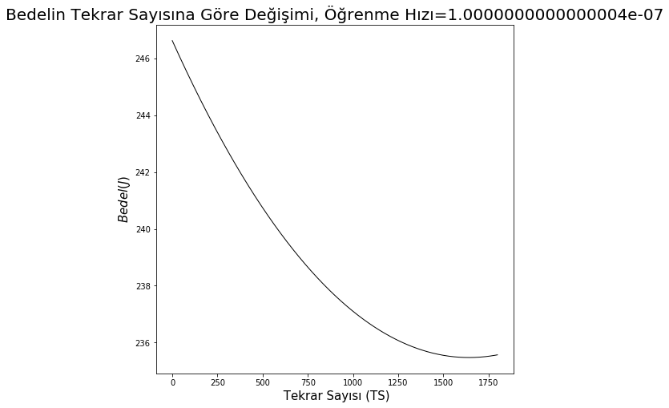

```python
plt.figure(figsize=(8,8))
title="Bedelin Tekrar Sayısına Göre Değişimi, Öğrenme Hızı="+str(a)
plt.title(title,fontsize="20")
plt.ylabel("$Bedel(J) $",fontsize=15)
plt.xlabel(" Tekrar Sayısı (TS)",fontsize=15)
plt.plot(bedel_df["index"],bedel_df["Bedel"], 'k-',linewidth=1,markersize=18)
plt.show()
```

```python
opts = {'maxiter' : 5000,    # default value.
         'disp' : True,    # non-default value.
          'gtol' : 1e-5,    # default value.
         'norm' : np.inf,  # default value.
          'eps' : 1.4901161193847656e-08}
```

```python
res1 = optimize.minimize(bedel,x0=param,jac=derece,args=(y_norm,n,lambda_), method='Nelder-Mead', options=opts)
```

```python
bedel(res1.x,y_norm,n,lambda_)
```

```
216.3236815819573
```

```python
nm=y.shape[0]

nu=y.shape[1]

r=-np.isnan(y_norm)*1

y_norm=y_norm.fillna(0)

X_n=res1.x[:nm*n].reshape(nm,n)

theta_n=res1.x[nm*n:].reshape(n,nu)
h=pd.DataFrame(np.dot(X_n,theta_n),index=y.index,columns=y.columns.tolist())
for i in h.columns:
    h[i]=h[i]+y_ort

h.head(3)
```

| title | 610(theta0) | 448(theta1) | 599(theta2) | 474(theta3) | 414(theta4) | 380(theta5) | 274(theta6) | 606(theta7) |
| --- | --- | --- | --- | --- | --- | --- | --- | --- |
| Apocalypse Now (1979) | 7.95845 | 8.849654 | 8.831581 | 8.747636 | 9.455060 | 9.770206 | 7.284206 | 8.287797 |
| Batman (1989) | 6.42222 | 8.221805 | 7.695311 | 8.190434 | 8.683336 | 8.674115 | 6.669492 | 7.955245 |
| Beverly Hills Cop (1984) | 7.38999 | 7.689313 | 7.821768 | 7.515058 | 8.298935 | 8.774249 | 6.239244 | 7.013866 |